# Análisis de la frecuencia relativa de observación de *O. garrula* en Barranquilla según los tipos de suelo contemplados en el POT 2012-2032 en el periodo 2015-2025

Autor/a

Nelson Pulecio

Fecha de publicación

26 de octubre de 2026

Palabras clave

-Barranquilla -Avifauna

## Introducción

La *Ortalis garrula*, cuyo nombre común es guacharaca, fue clasificada por primera vez por Humboldt en 1805 (OLIVARES 1966) y se considera uno de los símbolos representativos de la región Caribe al ser una especie endémica colombiana (solo tiene distribución en Colombia) cuyas poblaciones están mayormente centradas en la región Caribe, donde tiene fuertes relaciones con la cultura, por ejemplo, Peralta Agudelo (2025) resalta que las plumas de *Ortalis garrula* se consideran de buena suerte entre las comunidades campesinas del rió Sinú. Aunque esta ave también tiene distribución en la región Andina y reducidas poblaciones en la región Pacífica. a nivel morfológico *Ortalis garrula* es un ave de tamaño mediano la cual no tiene dimorfismo sexual (machos y hembras son físicamente iguales) y se caracteriza por un plumaje de tonos marrones en el lomo, tonos rojizos bajo el pico y las alas, así como tonos blanquecinos en el vientre y las patas.

Actualmente *Ortalis garrula* es considerada una especie sombrilla para la región caribe, lo que quiere decir que el cuidado de las poblaciones de esta ave y su habitad implica un cuidado de diversas especies y ecosistemas asociados a ella. Respecto a su alimentación, Setina et al. (2012) resalta que su dieta se compone de los frutos de *Brosimum utile, Eugenia oblongifolia, Ficus sp., Miconia sp., Psychotria sp., y Bellusia sp.* junto con el consumo de insectos, alimentación relacionada a su preferencia por bosques primarios y secundarios a diferencias de zonas en recuperación o cultivos agrícolas. Aunque *Ortalis garrula* está clasificada como LC, es decir, preocupación menor por la UICN («The IUCN Red List of Threatened Species», s. f.) se considera según los criterios de la AICAS (Áreas importantes para la conservación de las aves y la biodiversidad) como una especie de distribución restringida.

## Materiales y métodos

### Área de estudio

Entre las tantas divisiones que puede tener la ciudad, una de las que presenta el POT emitido por la Alcaldía de Barranquilla (2014) divide la ciudad en cuatro tipos de suelo principales (Figura 1) , entre los cuales se encuentra el suelo urbano en donde el proceso de urbanización está consolidado, el suelo de expansión urbana que se describe como suelo en donde el proceso de urbanización puede continuar en el POT vigente o en el futuro, el suelo rural el cual no puede ser urbanizado por diversas causas y el suelo en protección, dicha categoría puede estar incluida dentro de cualquiera de los suelos anteriores y por diversas causas como pueden serlo paisajísticas o ambientales está restringida la urbanización. Por esta razón, para este estudio, dicho tipo de suelo se encuentra indexado en su respectiva categoría como parte de esta.

**Código**

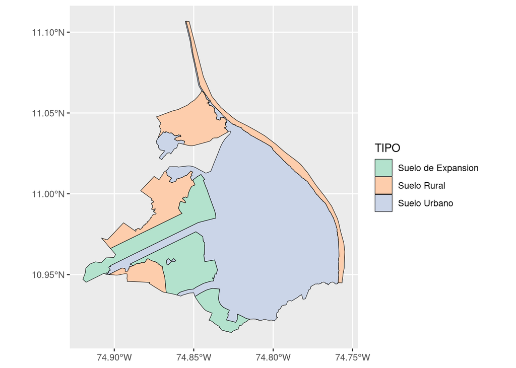

Figura 1: Mapa de la ciudad de barranquilla dividido según el tipo de suelo contemplado en el POT vigente 2012-2032, datos tomados de (Pallares, s. f.)

```r
#Cargar las librerias necesarias para correr el codigo, usando la función suppresspackagesstartupmessages({}) para suprimir los mensajes que aparecen al cargar las librerias.

suppressPackageStartupMessages({
  library(here)
  library(sf)
  library(ggplot2)
})

#Carga los datos necesarios para crear el mapa, usando la libreria here para facilitar escribir las rutas de los archivos y la funcion st_read para leer los archivos con datos geoespaciales

datos_mapa <- here(
  "data", "raw_data", "raw_datos_espaciales",
  "clasificacion_de_suelo_bq.json"
) |> st_read(quiet = T)

#crea el mapa con los datos geoespaciales y rellena con color el area usando la columna TIPO que contiene el tipo de suelo.

mapa <- ggplot(datos_mapa) +
  geom_sf(aes(fill = TIPO), color = "black") +
  scale_fill_brewer(palette = "Pastel2")

mapa
```

### Obtención de la información

Los datos de presencia para la ciudad de Barranquilla relacionados a este proyecto se obtuvieron mediante la plataforma [Gbif](https://www.gbif.org/es/) utilizando los filtros de registro de presencia donde se puso el estado presente, año en donde se puso el periodo 2015-2025, nombre científico donde se puso el filtro aves y localización/ubicación usando las geometrías de los polígonos correspondientes a cada tipo de suelo.

Los datos geoespaciales son originalmente derivados del portal de ArcGIS de la ciudad de Barranquilla y convertidos mediante la ArcGIS REST API, los datos fueron recuperados por Pallares (s. f.) mediante su repositorio de github. Los polígonos resultantes fueron separados por tipo de suelo mediante google earth y convertidos a wkt mediante [Mapryx](https://mapryx.geoforger.com/tools/geojson-wkt-converter) para poder ser utilizados como filtro geometrico en gbif.

### Limpieza de los datos

Originalmente los datos geoespaciales obtenido mediante el repositorio de (Pallares, s. f.) están separados por capa, por lo que mediante la herramienta Google earth se separó cada tipo de suelo con la intención obtener los datos de registro de presencia de las aves separados por tipo de suelo.

Dichos datos contienen información irrelevante para el estudio por lo que se hizo una limpieza de los datos, eliminando las variables que no eran relevantes y agregando una variable identificadora para cada tipo de suelo con la intención de facilitar los análisis estadísticos y gráficas, los valores NA en la columna “individualCount” fueron remplazados por 1, conjuntamente, se creó un único csv con todos los registros. A continuación se presenta el script correspondiente a la limpieza y unificación de los datos.

**Codigo de limpieza y unificación de datos**

```r
library(dplyr)

# En este script se realiza el proceso de limpieza de los datos que corresponden a los
# registros de presencia de las aves en los distintos tipos de suelo. Como es el mismo proceso
# para los tres tipos de suelo y por ende es el mismo codigo, solo se documenta en suelo rural
# el proceso de limpieza, luego el proceso de unificación de los data frames.

#--------------- SUELO RURAL ---------------------------------------

suelo_rural <- read_delim("data/raw_data/raw_datos_avistamiento/suelo_rural.csv",
                          delim = "\t", escape_double = FALSE,
                          col_types = cols(datasetKey = col_skip()),
                          trim_ws = TRUE) #Importa los datos en crudo

#Elimina los NA de la columna de conteo individual
# usando indexación logica de vecotres, remplazando
# los NA por 1.

suelo_rural$individualCount[is.na(suelo_rural$individualCount)] <- 1

#Seleciona solo las columnas de interés para el estudio,
#con la funcion select() y agrega la columna floorType a
#todas las filas del data frame con mutate()

suelo_rural_limpio <- suelo_rural |> select(species, individualCount,
                      decimalLatitude, decimalLongitude, month, year)|>
                      mutate(floorType = "rural")

##guarda el data frame resultante en un csv con el nombre
#"suelo_rural_limpio.csv"

write.csv(suelo_rural_limpio, file = "suelo_rural_limpio.csv", row.names = F)

#------------------ SUELO EN EXPANSIÓN ................................

suelo_en_expansion <- read_delim("data/raw_data/raw_datos_avistamiento/suelo_en_expansion.csv",
                                 delim = "\t", escape_double = FALSE,
                                 trim_ws = TRUE)

suelo_en_expansion$individualCount[is.na(suelo_en_expansion$individualCount)] <- 1

suelo_en_expansion_limpio <- suelo_en_expansion |> select(species, individualCount,
                             decimalLatitude, decimalLongitude, month, year)|>
                             mutate(floorType = "en expansión")

write.csv(suelo_en_expansion_limpio, file = "suelo_en_expansion_limpio.csv", row.names = F)

#------------------ SUELO URBANO -----------------------------------------

suelo_urbano <- read_delim("data/raw_data/raw_datos_avistamiento/suelo_urbano.csv",
                           delim = "\t", escape_double = FALSE,
                           trim_ws = TRUE)

suelo_urbano$individualCount[is.na(suelo_urbano$individualCount)] <- 1

suelo_urbano_limpio <-  suelo_urbano |> select(species, individualCount,
                        decimalLatitude, decimalLongitude, month, year)|>
                        mutate(floorType = "urbano")

write.csv(suelo_urbano, file = "suelo_urbano_limpio.csv", row.names = F)

#------------UNIÓN DE LOS CSV Y CREACION DEL NUEVO---------------------------------------

#Usa la funcion bind_rows() para unir los
#data frames ya creados en un solo csv.

csv_unido <- bind_rows(suelo_urbano_limpio, suelo_en_expansion_limpio, suelo_rural_limpio) |>
  write.csv(file = "registros_avistamiento_todos_los_suelos.csv")
```

### Análisis de datos y tabla de variables

**Código**

```r
# a continuación el código referente a la creación de la tabla de variables,
# creando un data frame con las filas de cada varible, utilizando la libreria
# tinytable para crear la tabla con la función tt()

library(tinytable)

tabla <- data.frame(
Nombre = c("Especies", "Conteo individual", "Latitud", "Longitud", "Años", "Tipo de suelo",
           "frecuencia relativa", "frecuencia"),
Tipo = c("Cualitativa nominal", "Cuantitativa discreta", "Cuantitativa discreta",
         "Cuantitativa discreta", "Cuantitativa continua", "Cualitativa nominal",
         "cuantitativa discreta", "cuantitativa discreta"),
Unidad = c("NA", "NA", "grados decimales (°)", "grados decimales (°)", "año (t)", "NA",
           "NA", "NA"),
Etiqueta = c("species", "individualCount", "decimalLatitude", "decimalLongitude", "year",
             "floorType", "Rfrecuency", "frecuency")
)

tt(tabla)
```

Tabla 1: Datos manipulados durante el análisis de los datos, donde “Nombre” corresponde al nombre con el que se va a referir a la variable en el texto y “Etiqueta” al nombre que tiene dicha variable en los scripts.

| Nombre | Tipo | Unidad | Etiqueta |
| --- | --- | --- | --- |
| Especies | Cualitativa nominal | NA | species |
| Conteo individual | Cuantitativa discreta | NA | individualCount |
| Latitud | Cuantitativa discreta | grados decimales (°) | decimalLatitude |
| Longitud | Cuantitativa discreta | grados decimales (°) | decimalLongitude |
| Años | Cuantitativa continua | año (t) | year |
| Tipo de suelo | Cualitativa nominal | NA | floorType |
| frecuencia relativa | cuantitativa discreta | NA | Rfrecuency |
| frecuencia | cuantitativa discreta | NA | frecuency |

## Referencias

Alcaldía de Barranquilla, Industrial y Portuario Distrital de Barranquilla, Distrito Especial. 2014. *PLAN DE ORDENAMIENTO TERRITORIAL 2012 - 2032*. febrero 28. https://barranquilla.gov.co/plan-de-ordenamiento-territorial.

OLIVARES, ANTONIO. 1966. «Introduccion a La Historia de La Ornitologia Colombiana». *Revista de la Academia Colombiana de Ciencias Exactas, Físicas y Naturales* (Bogotá, Colombia) 12 (48): 367-75. https://doi.org/raccefyn.12(48).1966.3479.

Pallares, Luis. s. f. «Panchicore/Barranquilla_geojson: Barranquilla GEOJSON Files». Github. Accedido 24 de octubre de 2026. https://github.com/panchicore/barranquilla_geojson.

Peralta Agudelo, Jaime Andrés. 2025. «De brujas, talismanes y otras «hechicerías». Las aves y lo sobrenatural en las comunidades campesinas del río Sinú». *Tabula Rasa*, n.º 56 (diciembre): 123-46. https://doi.org/10.25058/20112742.n56.06.

Romañas, Jorge, Erick Vidal, y Lizeth Rodríguez Potes. 2014. *UNA MIRADA AL SUROCCIDENTE DE BARRANQUILLA: PROBLEMÁTICA URBANA Y SOCIO-ECONÓMICA*. julio 31. https://repositorio.cuc.edu.co/entities/publication/ad290b44-64bc-47c0-869b-4d7b2f4da61b.

Setina, Víctor, Angélica Camargo, y Liliana Solano. 2012. *3.- ARTICULOS y NOTAS*. 34.

«The IUCN Red List of Threatened Species». s. f. IUCN Red List of Threatened Species. Accedido 26 de septiembre de 2026. https://www.iucnredlist.org/es.